# Terminology in Statistics

Niall McGuinness

2022-11-30

# 1 Useful Links

- [Color in R](https://www.programiz.com/r/colors#:~:text=We%20define%20a%20color%20as,and%20%23000000%20would%20be%20black.)
- [R Markdown Cookbook](https://bookdown.org/yihui/rmarkdown-cookbook/)
- [R Markdown Cheatsheet](https://www.rstudio.com/wp-content/uploads/2015/02/rmarkdown-cheatsheet.pdf)
- [R Markdown Theme Gallery](https://www.datadreaming.org/post/r-markdown-theme-gallery/)
- [An overview of color names in R](https://r-graph-gall%20ery.com/42-colors-names.html)
- [Top 7 Packages for Making Beautiful Tables in R](https://towardsdatascience.com/top-7-packages-for-making-beautiful-tables-in-r-7683d054e541)
- [Beautiful tables in R with gtExtras](https://themockup.blog/posts/2022-06-13-gtextras-cran/)
- [Understanding YAML headers](https://zsmith27.github.io/rmarkdown_crash-course/lesson-4-yaml-headers.html)
- [Setting up your R markdown YAML Header](https://zsmith27.github.io/rmarkdown_crash-course/lesson-4-yaml-headers.html)

# 2 What is markdown?

## 2.1 How can we add headings?

## 2.2 How can we add subheadings?

This is in **bold**. This is some *words* in italic.

This is a bulleted list: * Player - data * Customer - data

This is a numbered list: 1. Something 2. Something else

Can we add a link to the Dkit?

How should we add a table?

| Table Header | Second Header |
| --- | --- |
| Table Cell | Cell 2 |
| Cell 3 | Cell 4 |

# 3 What are the key terms in statistics?

## 3.1 What types of variables exist in a game-related survey?

- Name - character - “John”
- Gender - character - m/f/o/u
- Age - integer - 45, 32
- Satisfied - integer - 1->5, unsatisfied/satisfied
- Time - float-point - 2.25hrs
- Price - float-point - 2.25hrs

### 3.1.1 Define categories for the examples above

- Numerical - continuous, discrete e.g. height, age
- Categorical - nominal (name) e.g. “brown”, “male”, “satisfied”

## 3.2 What is a statistic?

- If we derive a value/variable from a sample we call it a statistic e.g. average age of a 100 people then we have a **sample statistic**.
- If we derive a value/variable from the population we call it a parameter e.g. census gives us average age of the population then we have a **population parameter**.

statistics -> samples parameters -> population

### 3.2.1 What is an example of a statistic?

```
##  [1] 3.2 2.0 5.1 1.0 4.0 5.0 3.0 2.2 1.0 4.0 5.1 1.0 2.8 3.3 1.0
```

```
## [1] 2.913333
```

```
## [1] 1
```

```
## [1] 3.5
```

This average of the data is 2.91 satisfaction points.

# 4 What can we plot with R Studio?

Well, we can generate plots really quickly from CSV file, or from remote RBDMS data, or from CSV file on web page.

### 4.0.1 Histogram

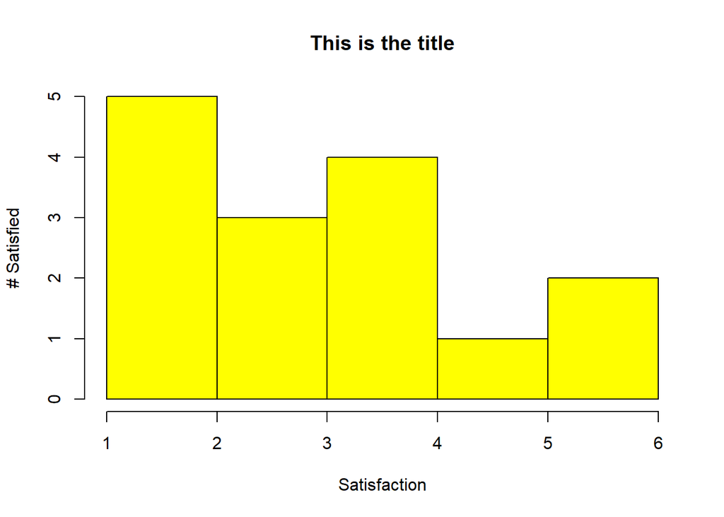

### 4.0.2 Barplot

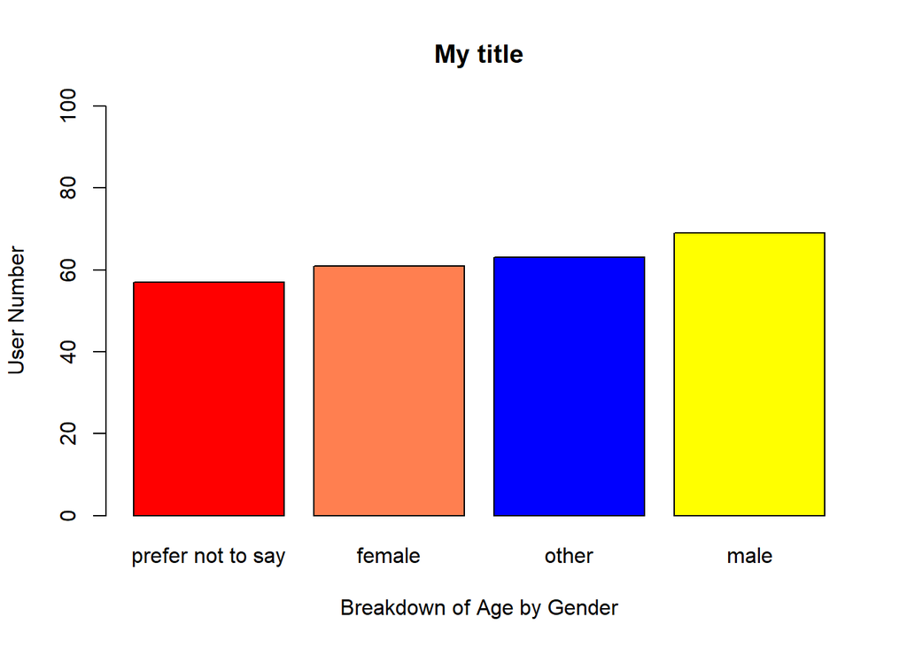

```r
gamer_survey_data <- read.csv("amalgamated_game_survey_250_2022.csv")
barplot(sort(table(gamer_survey_data$gender), decreasing = FALSE),
        main = "My title",
        xlab = "Breakdown of Age by Gender",
        ylab = "User Number",
        ylim = c(0, 100),
        col=c("red", "coral", "blue", "yellow"))
```

### 4.0.3 Boxplot

One box plot…

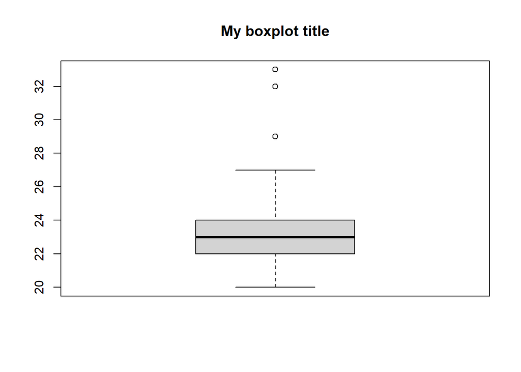

```r
boxplot(gamer_survey_data$age, main = "My boxplot title")
```

Multiple box plots…

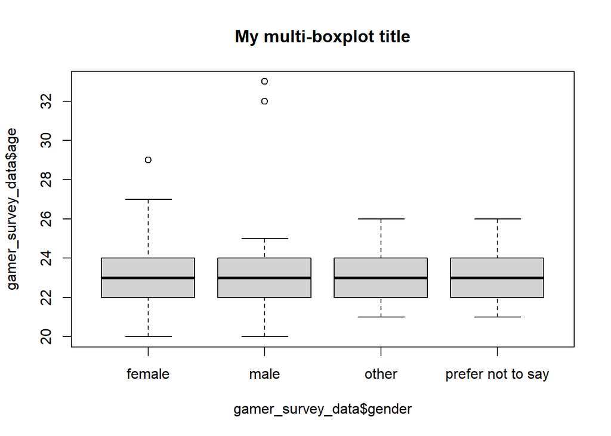

```r
boxplot(gamer_survey_data$age~gamer_survey_data$gender, main = "My multi-boxplot title")
```